# SDS 4030 - Statistics for Data Science II: Final Project

### Sibs

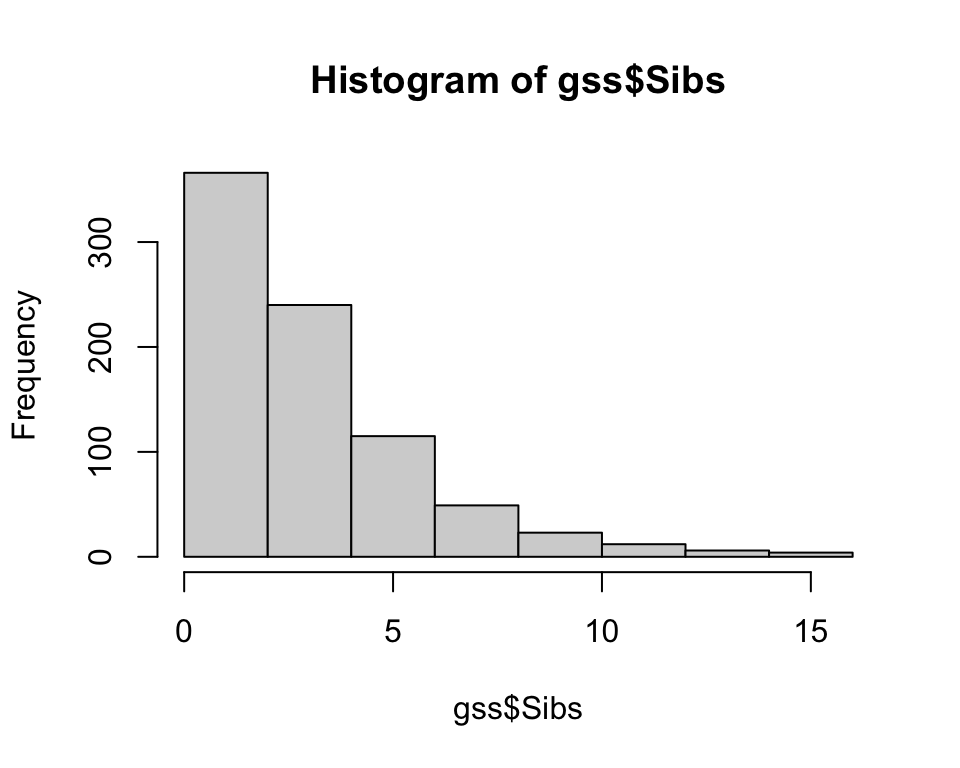

```r
hist(gss$Sibs)
```

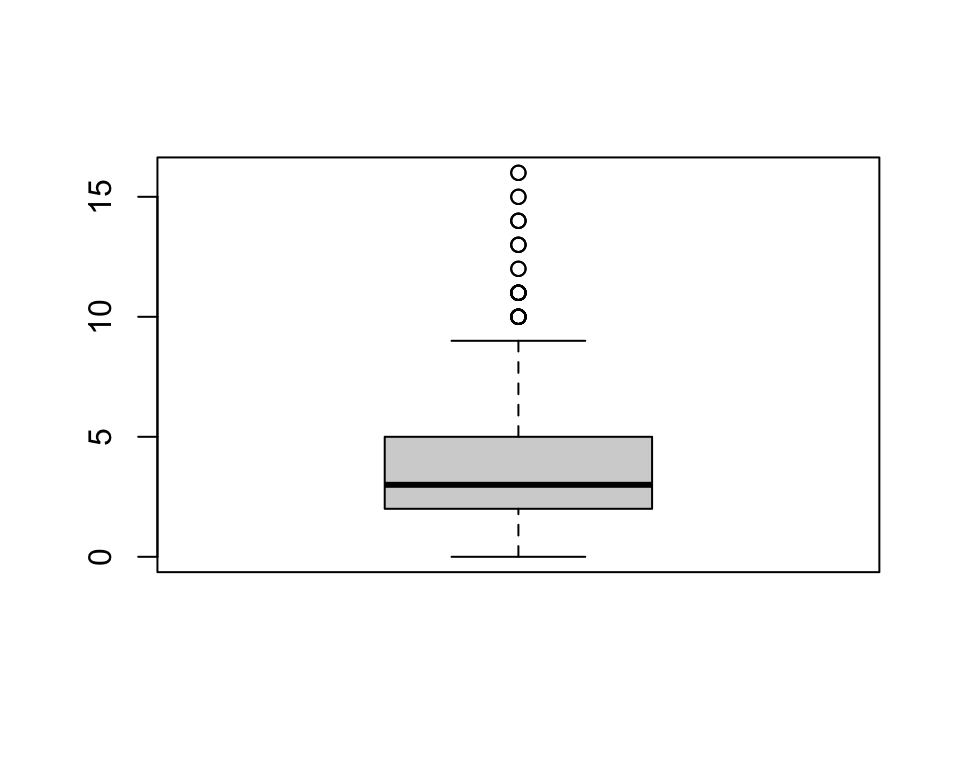

```r
boxplot(gss$Sibs)
```

The histogram for number of siblings is strongly right skewed, and the box plot is also right skewed with several high outliers. Like the TVHours, though slightly less skeweed, the Sibs covariate includes 0 so it could use a transformation like log(Sibs + 1) to reduce variance and skewness.

## ii) Should a transformation be applied to the response variable?

### Income

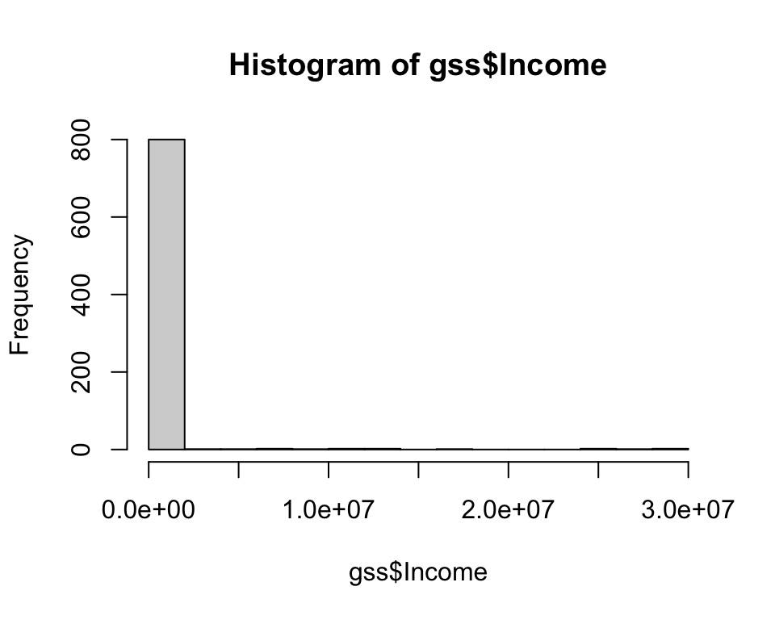

```r
hist(gss$Income)
```

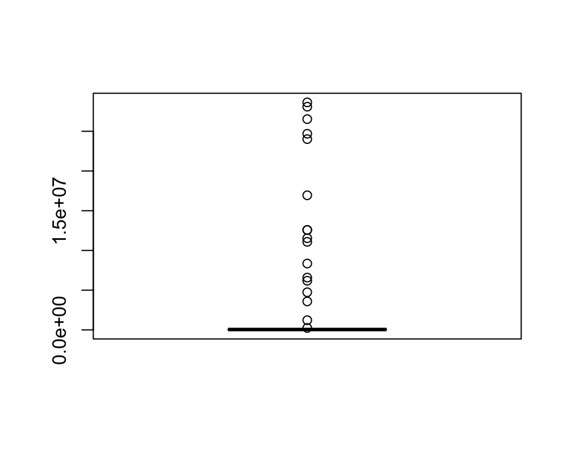

```r
boxplot(gss$Income)
```

The histogram for Income as expected is extremely right skewed and the boxplot for income is nowhere near normal as the median is all the way at the bottom and there are many high outliers. Based on this evidence it is plausible that a transformation of the response is appropriate. We should refit the model using transformed covariates for TVHours and Sibs then re-evaluate residual diagnostics and if violations still persist we will consider transforming the response variable Income using a Box-Cox transformation to diagnose which transformation is appropriate.

Now we will plot the fitted values and standardized residuals to detect violations of the assumptions of linear regression.

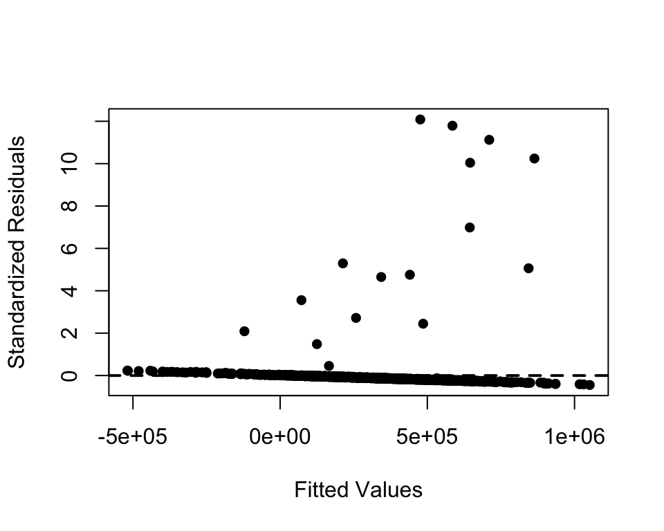

```r
fit = lm(Income ~ Age + Educ + Hours + log(TVHours + 1) + log(Sibs +
    1) + MEduc + FEduc, data = gss)
plot(fit$fitted.values, rstandard(fit), xlab = "Fitted Values", ylab = "Standardized Residuals",
    pch = 16)
abline(h = 0, lty = 2, lwd = 2)
```

After fitting the model with the transformed covariates, the residual plot still shows evidence for heteroscedasticity as the residuals are more concentrated around zero for smaller fitted values then we see large positive residuals at higher fitted values so residuals become more spread out as the fitted values increase, serving as an indicator for the violation of the constant variance assumption.

```r
Y = gss$Income
alpha = 0.05
lambda = seq(-2, 2, 0.01)
loglik = numeric(length(lambda))
for (i in 1:length(lambda)) {
    if (lambda[i] == 0) {
        Ypower = log(Y)
    } else {
        Ypower = (Y^lambda[i] - 1)/lambda[i]
    }
    power = lm(Ypower ~ Age + Educ + Hours + log(TVHours + 1) + MEduc +
        FEduc + log(Sibs + 1), data = gss)

    loglik[i] = logLik(power)[1] + (lambda[i] - 1) * sum(log(Y))
}
```

```r
CI = range(lambda[loglik > max(loglik) - qchisq(alpha, 1, lower.tail = FALSE)/2])
print(CI)
```

```
## [1] -0.14 -0.10
```

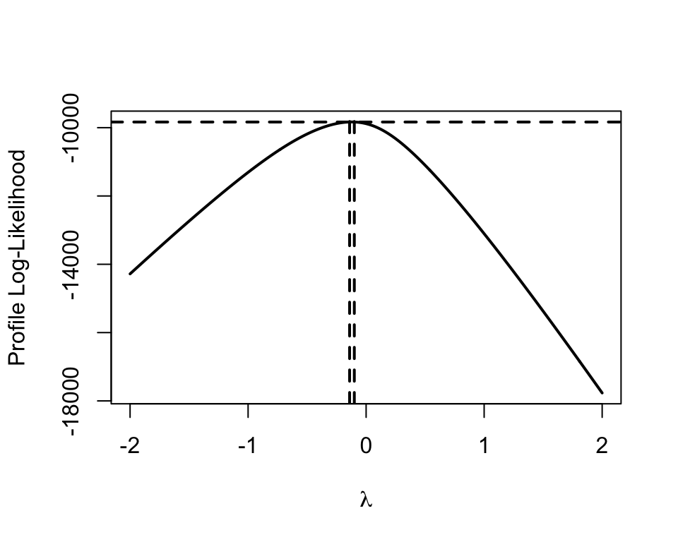

```r
plot(lambda, loglik, "l", xlab = expression(lambda), ylab = "Profile Log-Likelihood",
    lwd = 2)
abline(h = max(loglik) - qchisq(alpha, 1, lower.tail = FALSE)/2, lty = 2,
    lwd = 2)
abline(v = CI, lty = 2, lwd = 2)
```

If 0 is inside the CI then a log transformation is used, but the CI is [-0.14 -0.10] which does not include 0 but is very close. Since our response variable Income was was very skewed and needs a transformation and the optimal lambda is close to 0, a log transformation is reasonable. We confirm that a transformation be applied to the response variable.

## iii) Refit your linear model to account for all your transformed variables.

```r
fit_final = lm(log(Income) ~ Age + Educ + Hours + log(TVHours + 1) +
    MEduc + FEduc + log(Sibs + 1), data = gss)
```

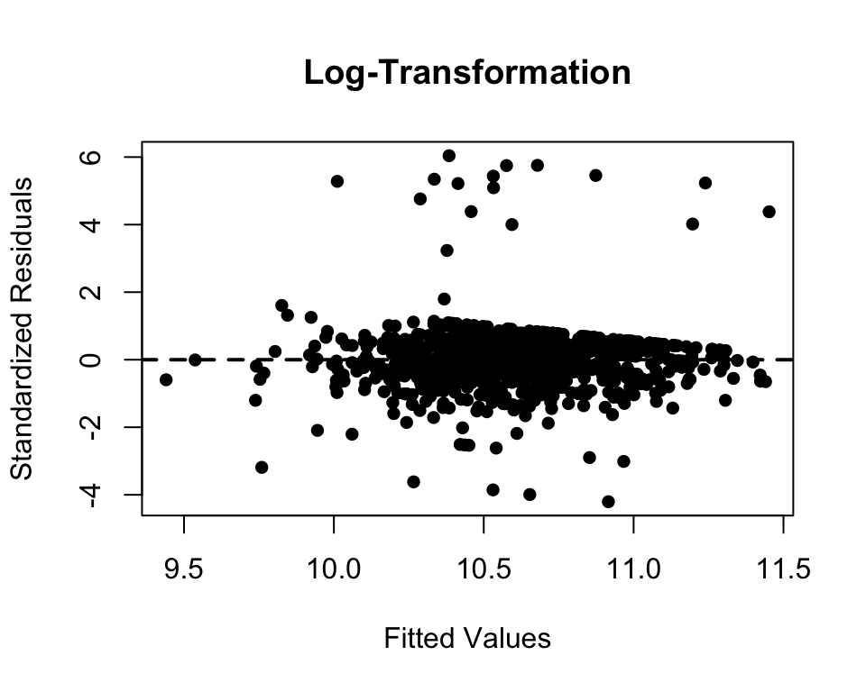

```r
plot(fit_final$fitted.values, rstandard(fit_final), main = "Log-Transformation",
    xlab = "Fitted Values", ylab = "Standardized Residuals", pch = 16)
abline(h = 0, lty = 2, lwd = 2)
```

This plot looks much better as the residuals are centered around 0 and the spread is much more constant across the fitted values. We no longer see dramatic patterns and this transformation significantly improved the model assumptions. We do not have evidence to suggest a violation of the linearity of homoscedasticity assumptions.

## iv) Are the standardized residuals from your linear model normally distributed?

```
## no dparams supplied. Estimating parameters from the data...
```

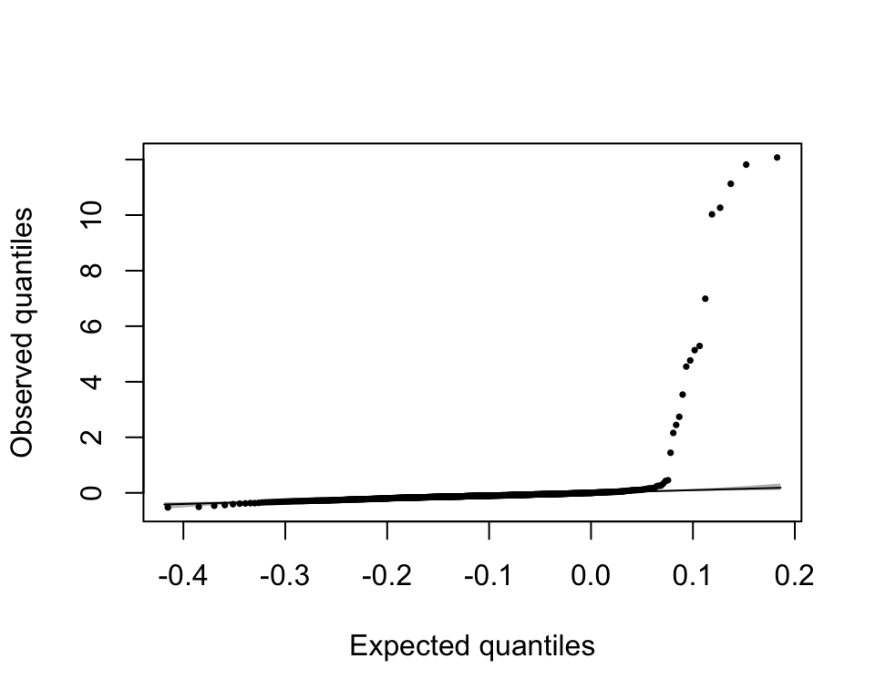

```r
library(qqconf)
qq_conf_plot(rstandard(full_model), points_params = list(pch = 16, cex = 0.5))
```

We use a Q-Q plot to display the observed quantiles of the sample against the expected quantiles of the null distribution. If the residuals were normally distributed we would expect the sample and theoretical quantiles to be in agreement and have the points form a straight line. We can see the points to not form a straight line at all as there is much deviation from the line at the higher end of the quantiles. Thus we have evidence for a deviation from linearity at the upper tail there is extreme upward curvature. This is consistent with our dataset as we found heavy right skeweness and extreme outliers. So no, the standardized residuals from the linear model are not normally distributed and there is evidence for the violation of the normality assumption.

## v) Construct 95 percent simultaneous confidence bands to test the global null hypothesis of normality for the standardized residuals.

The plot above draws 95% simultaneous confidence bands around the Q-Q plot line. As all points on the Q-Q plot line do not lie within the simultaneous confidence bands, particularly in the upper tail points are far outside of the bands, so we reject the null hypothesis of normality at the 5% level.

Step 8:

Use your transformed variables from now on.

1. Investigate the interaction effects between the 2 qualitative covariate which has been specified for your team and all available quantitative covariates on the response variable.
   - What has been specified to us: Investigate the interaction effects between work status and all available quantitative covariates on the response variable.
2. Formulate a suitable final model to draw inferences on the response variable and provide the interpretation of each type of coefficient in your final model.

## i) Investigate the interaction effects between the 2 qualitative covariate which has been specified for your team and all available quantitative covariates on the response variable.

```r
full_int <- lm(log(Income) ~ Work * (Age + Educ + Hours + log(TVHours +
    1) + MEduc + FEduc + log(Sibs + 1)), data = gss)
summary(full_int)
```

```
##
## Call:
## lm(formula = log(Income) ~ Work * (Age + Educ + Hours + log(TVHours +
##     1) + MEduc + FEduc + log(Sibs + 1)), data = gss)
##
## Residuals:
##     Min      1Q  Median      3Q     Max
## -4.7336 -0.4665  0.0148  0.4100  6.8045
##
## Coefficients: (2 not defined because of singularities)
##                                     Estimate Std. Error t value Pr(>|t|)
## (Intercept)                        8.7815922  0.4684805  18.745  < 2e-16 ***
## WorkHousekeeping                  -1.7311362  1.5072929  -1.149  0.25112
## WorkLaid Off                       3.4539344  8.5312680   0.405  0.68570
## WorkNot Working                   -3.3742289  5.3420864  -0.632  0.52782
## WorkOther                         -5.6959180 11.6695883  -0.488  0.62562
## WorkParttime                       2.6917511  1.1564454   2.328  0.02020 *
## WorkRetired                        0.5030868  2.1874593   0.230  0.81816
## WorkSchool                         7.7889612  6.4313348   1.211  0.22624
## Age                                0.0135097  0.0044665   3.025  0.00257 **
## Educ                               0.0825263  0.0206934   3.988 7.31e-05 ***
## Hours                              0.0010146  0.0043255   0.235  0.81461
## log(TVHours + 1)                  -0.1947840  0.1094176  -1.780  0.07545 .
## MEduc                             -0.0082997  0.0191054  -0.434  0.66411
## FEduc                              0.0281617  0.0165624   1.700  0.08948 .
## log(Sibs + 1)                      0.1216572  0.0900660   1.351  0.17718
## WorkHousekeeping:Age               0.0007984  0.0126450   0.063  0.94967
## WorkLaid Off:Age                   0.0370831  0.0910906   0.407  0.68405
## WorkNot Working:Age               -0.1128065  0.1167466  -0.966  0.33423
## WorkOther:Age                      0.0135811  0.0766288   0.177  0.85937
## WorkParttime:Age                   0.0102467  0.0101200   1.013  0.31162
## WorkRetired:Age                   -0.0254000  0.0192396  -1.320  0.18717
## WorkSchool:Age                     0.0025342  0.0392249   0.065  0.94850
## WorkHousekeeping:Educ             -0.0427066  0.0686667  -0.622  0.53417
## WorkLaid Off:Educ                 -0.0993491  0.6328440  -0.157  0.87530
## WorkNot Working:Educ               0.5730530  0.4482570   1.278  0.20150
## WorkOther:Educ                     0.3171202  0.5450908   0.582  0.56089
## WorkParttime:Educ                 -0.1338918  0.0556635  -2.405  0.01640 *
## WorkRetired:Educ                   0.0776308  0.0864866   0.898  0.36968
## WorkSchool:Educ                   -0.2931145  0.1824101  -1.607  0.10850
```

[output cut: 26 more lines]

```
## WorkRetired:FEduc                 -0.0485290  0.0566812  -0.856  0.39217
## WorkSchool:FEduc                  -0.2347872  0.2282919  -1.028  0.30407
## WorkHousekeeping:log(Sibs + 1)     0.0083198  0.2918398   0.029  0.97726
## WorkLaid Off:log(Sibs + 1)        -0.6295618  1.4804409  -0.425  0.67077
## WorkNot Working:log(Sibs + 1)      0.6286333  0.7795345   0.806  0.42025
## WorkOther:log(Sibs + 1)                   NA         NA      NA       NA
## WorkParttime:log(Sibs + 1)        -0.0605811  0.2444690  -0.248  0.80435
## WorkRetired:log(Sibs + 1)         -0.2720402  0.2997300  -0.908  0.36437
## WorkSchool:log(Sibs + 1)           0.0332938  0.5440693   0.061  0.95122
## ---
## Signif. codes:  0 '***' 0.001 '**' 0.01 '*' 0.05 '.' 0.1 ' ' 1
##
## Residual standard error: 1.119 on 753 degrees of freedom
## Multiple R-squared:  0.1437, Adjusted R-squared:  0.07435
## F-statistic: 2.072 on 61 and 753 DF,  p-value: 7.01e-06
```

Work has 8 levels, so we have 7 dummy variables times our have 7 quantitative variables, so 49 interaction terms. We want to reduce our model to avoid over fitting. We perform backward elimination since we already have our linear model with all possible covariates and interactions.

## ii) Formulate a suitable final model to draw inferences on the response variable and provide the interpretation of each type of coefficient in your final model.

We are using a backward elimination technique where we remove the lowest p-value per the ANOVA test, since we have quantitative and qualitative covariates.

```r
# anova(full_int)

full_int = update(full_int, . ~ . - Work:MEduc)
# anova(full_int)
full_int = update(full_int, . ~ . - Work:log(Sibs + 1))
# anova(full_int)
full_int = update(full_int, . ~ . - MEduc)
# anova(full_int)
full_int = update(full_int, . ~ . - Work:Hours)
# anova(full_int)
full_int = update(full_int, . ~ . - Work:FEduc)
# anova(full_int)
full_int = update(full_int, . ~ . - Work:Age)
# anova(full_int)
full_int = update(full_int, . ~ . - Hours)
# anova(full_int)
full_int = update(full_int, . ~ . - FEduc)
# anova(full_int)
full_int = update(full_int, . ~ . - Work:Educ)
# anova(full_int)
full_int = update(full_int, . ~ . - Work:log(TVHours + 1))
anova(full_int)
```

|  | Df | Sum Sq | Mean Sq | F value | Pr(>F) |
| --- | --- | --- | --- | --- | --- |
| Work | 7 | 42.271864 | 6.038838 | 4.883202 | 2.065025e-05 |
| Age | 1 | 17.532233 | 17.532233 | 14.177139 | 1.785156e-04 |
| Educ | 1 | 39.249804 | 39.249804 | 31.738679 | 2.440407e-08 |
| log(TVHours + 1) | 1 | 8.158554 | 8.158554 | 6.597274 | 1.039317e-02 |
| log(Sibs + 1) | 1 | 1.296402 | 1.296402 | 1.048313 | 3.062043e-01 |
| Residuals | 803 | 993.034151 | 1.236655 | NA | NA |

```r
summary(full_int)
```

```
##
## Call:
## lm(formula = log(Income) ~ Work + Age + Educ + log(TVHours +
##     1) + log(Sibs + 1), data = gss)
##
## Residuals:
##     Min      1Q  Median      3Q     Max
## -4.8316 -0.5004  0.0504  0.4226  6.7003
##
## Coefficients:
##                   Estimate Std. Error t value Pr(>|t|)
## (Intercept)       9.241059   0.313054  29.519  < 2e-16 ***
## WorkHousekeeping -0.530434   0.158620  -3.344 0.000864 ***
## WorkLaid Off      0.039932   0.373731   0.107 0.914937
## WorkNot Working  -0.541399   0.312714  -1.731 0.083784 .
## WorkOther         0.077172   0.459982   0.168 0.866805
## WorkParttime     -0.139585   0.121542  -1.148 0.251124
## WorkRetired      -0.892310   0.201476  -4.429 1.08e-05 ***
## WorkSchool       -0.439255   0.316057  -1.390 0.164975
## Age               0.011528   0.003294   3.499 0.000492 ***
## Educ              0.082639   0.015980   5.171 2.94e-07 ***
## log(TVHours + 1) -0.225616   0.085992  -2.624 0.008863 **
## log(Sibs + 1)     0.072470   0.070781   1.024 0.306204
## ---
## Signif. codes:  0 '***' 0.001 '**' 0.01 '*' 0.05 '.' 0.1 ' ' 1
##
## Residual standard error: 1.112 on 803 degrees of freedom
## Multiple R-squared:  0.09851,    Adjusted R-squared:  0.08616
## F-statistic: 7.977 on 11 and 803 DF,  p-value: 2.785e-13
```

After applying a backwards elimination technique on the transformed model, we get 12 predictors (including the intercept) as the lowest and best options for future predicitions.

Step 9:

Ignore all interaction effects from now on.

1. Fit a mixed-effects model with all available quantitative and qualitative covariates by appropriately treating some of your covariates as random effects. Determine a suitable transformation for your response variable.
2. Test the statistical significance of all your fixed effects.
3. Calculate the intraclass correlation coefficients corresponding to each of your random effects What percentage of the total variation in your response variable does each of your random effects explain?
4. What’s another interpretation for each intraclass correlation coefficient?

## i) Ignore all interaction effects from now on. Fit a mixed-effects model with all available quantitative and qualitative covariates by appropriately treating some of your covariates as random effects. Determine a suitable transformation for your response variable.

```r
library(lme4)

mixed_model = lmer(log(Income) ~ Age + Educ + Hours + log(TVHours + 1) +
    Happy + MEduc + FEduc + log(Sibs + 1) + Sex + (1 | Zodiac) + (1 |
    Marital) + (1 | Work), data = gss)

sigma = data.frame(summary(mixed_model)$varcor)$sdcor
names(sigma) = data.frame(summary(mixed_model)$varcor)$grp
ICC = sigma^2/sum(sigma^2)
print(ICC)
```

```
##      Zodiac        Work     Marital    Residual
## 0.003463625 0.053966054 0.055065667 0.887504654
```

```r
summary(mixed_model, correlation = FALSE)
```

```
## Linear mixed model fit by REML ['lmerMod']
## Formula: log(Income) ~ Age + Educ + Hours + log(TVHours + 1) + Happy +
##     MEduc + FEduc + log(Sibs + 1) + Sex + (1 | Zodiac) + (1 |
##     Marital) + (1 | Work)
##    Data: gss
##
## REML criterion at convergence: 2489.2
##
## Scaled residuals:
##     Min      1Q  Median      3Q     Max
## -4.2700 -0.4054 -0.0073  0.3117  5.9940
##
## Random effects:
##  Groups   Name        Variance Std.Dev.
##  Zodiac   (Intercept) 0.004464 0.06681
##  Work     (Intercept) 0.069556 0.26373
##  Marital  (Intercept) 0.070973 0.26641
##  Residual             1.143890 1.06953
## Number of obs: 815, groups:  Zodiac, 12; Work, 8; Marital, 5
##
## Fixed effects:
##                     Estimate Std. Error t value
## (Intercept)        8.2261484  0.4133664  19.900
## Age                0.0090210  0.0034370   2.625
## Educ               0.0774983  0.0166455   4.656
## Hours              0.0003294  0.0031349   0.105
## log(TVHours + 1)  -0.1774335  0.0839616  -2.113
## HappyPretty Happy  0.3758767  0.1381257   2.721
## HappyVery Happy    0.5157427  0.1477088   3.492
## MEduc             -0.0105824  0.0150634  -0.703
## FEduc              0.0231915  0.0131725   1.761
## log(Sibs + 1)      0.1351602  0.0706531   1.913
## SexMale            0.1229452  0.0791305   1.554
```

```r
Y = gss$Income
alpha = 0.05
lambda = seq(-2, 2, 0.01)
loglik = numeric(length(lambda))
for (i in 1:length(lambda)) {
    if (lambda[i] == 0) {
        Ypower = log(Y)
    } else {
        Ypower = (Y^lambda[i] - 1)/lambda[i]
    }
    power = lmer(Ypower ~ Age + Educ + Hours + log(TVHours + 1) + Happy +
        MEduc + FEduc + log(Sibs + 1) + Sex + (1 | Zodiac) + (1 | Marital) +
        (1 | Work), data = gss)

    loglik[i] = logLik(power)[1] + (lambda[i] - 1) * sum(log(Y))
}
```

```r
CI = range(lambda[loglik > max(loglik) - qchisq(alpha, 1, lower.tail = FALSE)/2])
print(CI)
```

```
## [1] -0.13 -0.09
```

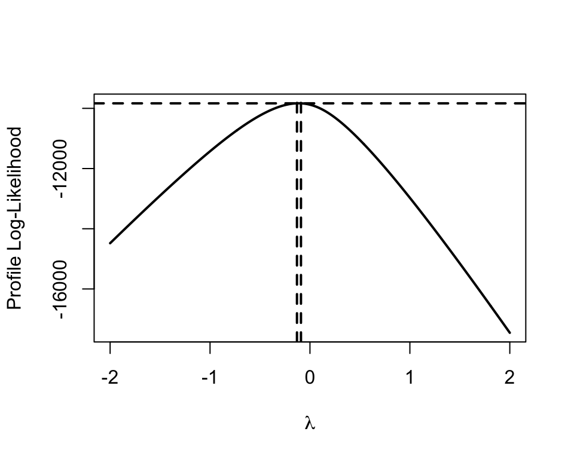

```r
plot(lambda, loglik, "l", xlab = expression(lambda), ylab = "Profile Log-Likelihood",
    lwd = 2)
abline(h = max(loglik) - qchisq(alpha, 1, lower.tail = FALSE)/2, lty = 2,
    lwd = 2)
abline(v = CI, lty = 2, lwd = 2)
```

If 0 is inside the CI then a log transformation is used, but the CI is [-0.13 -0.09] which does not include 0 but is very close. Which also backsup our previous transformation that we did prior, showing that a log transformation IS a suitable transformation even for this mixed effects model. The residuals show a range from $-4.27$ to $5.99$; the median is very close to zero ($-0.0073$) wihch suggests that the log transformation has done a good job of stabilizing the variance. So, we conclude that log(Income) is suitable even for this mixed effects model.

## ii) Test the statistical significance of all your fixed effects.

Statistical Significance Testing for Age:

```r
full = lmer(log(Income) ~ Age + Educ + Hours + log(TVHours + 1) + Happy +
    MEduc + FEduc + log(Sibs + 1) + Sex + (1 | Zodiac) + (1 | Marital) +
    (1 | Work), data = gss, REML = FALSE)
reduced = lmer(log(Income) ~ Educ + Hours + log(TVHours + 1) + Happy +
    MEduc + FEduc + log(Sibs + 1) + Sex + (1 | Zodiac) + (1 | Marital) +
    (1 | Work), data = gss, REML = FALSE)

LR = -2 * (logLik(reduced)[1] - logLik(full)[1])
pvalue = pchisq(LR, 5, lower.tail = FALSE)
print(pvalue)
```

```
## [1] 0.2997707
```

The p-value of the Likelihood Ratio test for the effect of Age on log(Income) is equal to 0.2997707.

Statistical Significance Testing for Educ:

```r
full = lmer(log(Income) ~ Age + Educ + Hours + log(TVHours + 1) + Happy +
    MEduc + FEduc + log(Sibs + 1) + Sex + (1 | Zodiac) + (1 | Marital) +
    (1 | Work), data = gss, REML = FALSE)
reduced = lmer(log(Income) ~ Age + Hours + log(TVHours + 1) + Happy +
    MEduc + FEduc + log(Sibs + 1) + Sex + (1 | Zodiac) + (1 | Marital) +
    (1 | Work), data = gss, REML = FALSE)
LR = -2 * (logLik(reduced)[1] - logLik(full)[1])
pvalue = pchisq(LR, 5, lower.tail = FALSE)
print(pvalue)
```

```
## [1] 0.000610675
```

The p-value of the Likelihood Ratio test for the effect of Educ on log(Income) is equal to 0.000610675.

Statistical Significance Testing for Hours:

```r
full = lmer(log(Income) ~ Age + Educ + Hours + log(TVHours + 1) + Happy +
    MEduc + FEduc + log(Sibs + 1) + Sex + (1 | Zodiac) + (1 | Marital) +
    (1 | Work), data = gss, REML = FALSE)
reduced = lmer(log(Income) ~ Age + Educ + log(TVHours + 1) + Happy +
    MEduc + FEduc + log(Sibs + 1) + Sex + (1 | Zodiac) + (1 | Marital) +
    (1 | Work), data = gss, REML = FALSE)

LR = -2 * (logLik(reduced)[1] - logLik(full)[1])
pvalue = pchisq(LR, 5, lower.tail = FALSE)
print(pvalue)
```

```
## [1] 0.9999998
```

The p-value of the Likelihood Ratio test for the effect of Hours on log(Income) is equal to 0.9999998

Statistical Significance Testing for log(TVHours + 1):

```r
full = lmer(log(Income) ~ Age + Educ + Hours + log(TVHours + 1) + Happy +
    MEduc + FEduc + log(Sibs + 1) + Sex + (1 | Zodiac) + (1 | Marital) +
    (1 | Work), data = gss, REML = FALSE)
reduced = lmer(log(Income) ~ Age + Educ + Hours + Happy + MEduc + FEduc +
    log(Sibs + 1) + Sex + (1 | Zodiac) + (1 | Marital) + (1 | Work),
    data = gss, REML = FALSE)

LR = -2 * (logLik(reduced)[1] - logLik(full)[1])
pvalue = pchisq(LR, 5, lower.tail = FALSE)
print(pvalue)
```

```
## [1] 0.4771
```

The p-value of the Likelihood Ratio test for the effect of log(TVHours + 1) on log(Income) is equal to 0.4771

Statistical Significance Testing for Happy:

```r
full = lmer(log(Income) ~ Age + Educ + Hours + log(TVHours + 1) + Happy +
    MEduc + FEduc + log(Sibs + 1) + Sex + (1 | Zodiac) + (1 | Marital) +
    (1 | Work), data = gss, REML = FALSE)
reduced = lmer(log(Income) ~ Age + Educ + Hours + log(TVHours + 1) +
    MEduc + FEduc + log(Sibs + 1) + Sex + (1 | Zodiac) + (1 | Marital) +
    (1 | Work), data = gss, REML = FALSE)

LR = -2 * (logLik(reduced)[1] - logLik(full)[1])
pvalue = pchisq(LR, 5, lower.tail = FALSE)
print(pvalue)
```

```
## [1] 0.0296004
```

The p-value of the Likelihood Ratio test for the effect of Happy on log(Income) is equal to 0.0296004.

Statistical Significance Testing for MEduc:

```r
full = lmer(log(Income) ~ Age + Educ + Hours + log(TVHours + 1) + Happy +
    MEduc + FEduc + log(Sibs + 1) + Sex + (1 | Zodiac) + (1 | Marital) +
    (1 | Work), data = gss, REML = FALSE)
reduced = lmer(log(Income) ~ Age + Educ + Hours + log(TVHours + 1) +
    Happy + FEduc + log(Sibs + 1) + Sex + (1 | Zodiac) + (1 | Marital) +
    (1 | Work), data = gss, REML = FALSE)

LR = -2 * (logLik(reduced)[1] - logLik(full)[1])
pvalue = pchisq(LR, 5, lower.tail = FALSE)
print(pvalue)
```

```
## [1] 0.9921011
```

The p-value of the Likelihood Ratio test for the effect of MEduc on log(Income) is equal to 0.9921011

Statistical Significance Testing for FEduc:

```r
full = lmer(log(Income) ~ Age + Educ + Hours + log(TVHours + 1) + Happy +
    MEduc + FEduc + log(Sibs + 1) + Sex + (1 | Zodiac) + (1 | Marital) +
    (1 | Work), data = gss, REML = FALSE)
reduced = lmer(log(Income) ~ Age + Educ + Hours + log(TVHours + 1) +
    Happy + MEduc + log(Sibs + 1) + Sex + (1 | Zodiac) + (1 | Marital) +
    (1 | Work), data = gss, REML = FALSE)

LR = -2 * (logLik(reduced)[1] - logLik(full)[1])
pvalue = pchisq(LR, 5, lower.tail = FALSE)
print(pvalue)
```

```
## [1] 0.6757152
```

The p-value of the Likelihood Ratio test for the effect of FEduc on log(Income) is equal to 0.6757152

Statistical Significance Testing for log(Sibs + 1):

```r
full = lmer(log(Income) ~ Age + Educ + Hours + log(TVHours + 1) + Happy +
    MEduc + FEduc + log(Sibs + 1) + Sex + (1 | Zodiac) + (1 | Marital) +
    (1 | Work), data = gss, REML = FALSE)
reduced = lmer(log(Income) ~ Age + Educ + Hours + log(TVHours + 1) +
    Happy + MEduc + FEduc + Sex + (1 | Zodiac) + (1 | Marital) + (1 |
    Work), data = gss, REML = FALSE)

LR = -2 * (logLik(reduced)[1] - logLik(full)[1])
pvalue = pchisq(LR, 5, lower.tail = FALSE)
print(pvalue)
```

```
## [1] 0.5954642
```

The p-value of the Likelihood Ratio test for the effect of log(Sibs + 1) on log(Income) is equal to 0.5954642

Statistical Significance Testing for Sex:

```r
full = lmer(log(Income) ~ Age + Educ + Hours + log(TVHours + 1) + Happy +
    MEduc + FEduc + log(Sibs + 1) + Sex + (1 | Zodiac) + (1 | Marital) +
    (1 | Work), data = gss, REML = FALSE)
reduced = lmer(log(Income) ~ Age + Educ + Hours + log(TVHours + 1) +
    Happy + MEduc + FEduc + log(Sibs + 1) + (1 | Zodiac) + (1 | Marital) +
    (1 | Work), data = gss, REML = FALSE)

LR = -2 * (logLik(reduced)[1] - logLik(full)[1])
pvalue = pchisq(LR, 5, lower.tail = FALSE)
print(pvalue)
```

```
## [1] 0.7789858
```

The p-value of the Likelihood Ratio test for the effect of Sex on log(Income) is equal to 0.7789858

Out of every fixed effect covariate, the only statistically significant ones were Educ (p-value of 0.000610675) and Happy (p-value of 0.0296004). Every other fixed effect covariate remained statistically insignificant as their p-values through the Likelihood Ratio test were above the alpha threshold of 0.05.

## iii) Calculate the intraclass correlation coefficients corresponding to each of your random effects. What percentage of the total variation in your response variable does each of your random effects explain?

Zodiac Intraclass Correlation Coefficient:

```r
ICC_Zodiac = (0.004464/(0.004464 + 0.069556 + 0.070973 + 1.14389))
ICC_Zodiac
```

```
## [1] 0.003463464
```

Zodiac explains roughly $0.35\%$ of the total variation in log(Income), which is extremely, extremely small. It has very low similarities between observations within the same group. TTwo people with the same Zodiac status, the predicted correlation between their log-incomes is $0.0034$.

Work Intraclass Correlation Coefficient:

```r
ICC_Sibs = (0.069556/(0.004464 + 0.069556 + 0.070973 + 1.14389))
ICC_Sibs
```

```
## [1] 0.05396611
```

Work explains roughly $5.4\%$ of the total variation in log(Income), which is pretty small. It has low similarities between observations within the same group. Two people with the same Work status, the predicted correlation between their log-incomes is $0.054$.

Marital Intraclass Correlation Coefficient:

```r
ICC_Marital = (0.070973/(0.004464 + 0.069556 + 0.070973 + 1.14389))
ICC_Marital
```

```
## [1] 0.05506551
```

Marital explains roughly $5.5\%$ of the total variation in log(Income), which is pretty small. It has low similarities between observations within the same group. Two people with the same marital status, the predicted correlation between their log-incomes is $0.055$.

Residual Intraclass Correlation Coefficient:

```r
ICC_Marital = (1.14389/(0.004464 + 0.069556 + 0.070973 + 1.14389))
ICC_Marital
```

```
## [1] 0.8875049
```

The residuals explain $88.75\%$ of the total varition in log(Income), this means most of the total variation in log(Income) can not be explained by our random variables. Which is not optimal for our linear model, since we would rather have a higher degree of total variability in log(Income) be explained by our covaraites rather than just residuals.

## iv) What’s another interpretation for each intraclass correlation coefficient?

The ICC represents the expected correlation between log(Income) of two different individuals who belong to the same group, examples stated above in section iii just above. ICC is a measure of within group similarity. A higher ICC means that individuals within the same category are more alike regarding their income than individuals chosen from the population at large. And we do not particullary have any large ICC’s for our variables, which indicates that there may not be a lot of simularity between our random groups.

Step 10:

Ignore all random effects from now on.

## i) Apply a suitable model selection method and draw valid inferences on the response variable.

## i) Apply a suitable model selection method and draw valid inferences on the response variable.

Using a Backward Elimination with Valid Post-Selection Inference to formulate a good final model to draw inferences on Income. A 60 | 20 | 20 stadnard validation split (60 for training 20 for validation 20 for testing).

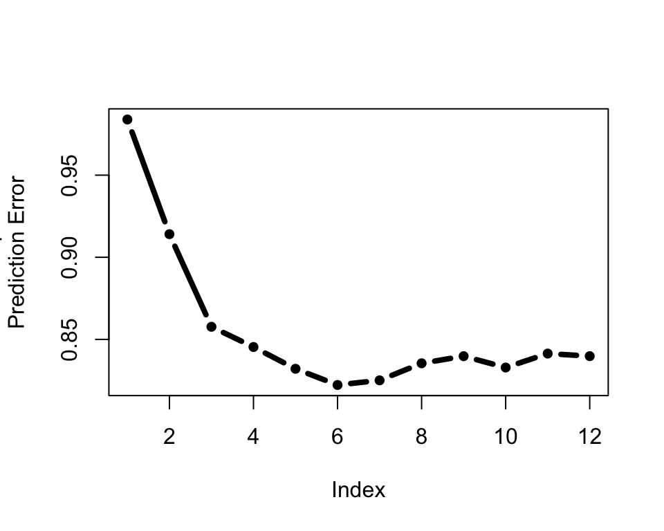

```r
set.seed(0)
Y = log(gss$Income)
X = gss[, -11]
n = dim(X)[1]
P = dim(X)[2]

train = sample(n, floor(0.6 * n))
valid = sample(setdiff(1:n, train), floor(0.2 * n))
test = setdiff(1:n, c(train, valid))
MSPE = numeric(P)

for (p in P:1) {
    fit = lm(Y ~ ., data = X[, 1:p, drop = FALSE], subset = train)

    predictions = predict(fit, newdata = X[valid, 1:p, drop = FALSE])
    MSPE[p] = mean((Y[valid] - predictions)^2)

    a = drop1(fit, test = "F")
    ind = which.max(a[-1, "Pr(>F)"])

    if (ind != p) {
        X[, c(ind, p)] = X[, c(p, ind)]
        names(X)[c(ind, p)] = names(X)[c(p, ind)]
    }
}

plot(MSPE, type = "b", pch = 16, lwd = 4, ylab = "Mean Squared\nPrediction Error")
```

```r
p = which.min(MSPE)
fit = lm(Y ~ ., data = X[, 1:p, drop = FALSE], subset = c(train, valid))
summary(fit)
```

```
##
## Call:
## lm(formula = Y ~ ., data = X[, 1:p, drop = FALSE], subset = c(train,
##     valid))
##
## Residuals:
##     Min      1Q  Median      3Q     Max
## -4.5632 -0.3850  0.0899  0.4116  3.9081
##
## Coefficients:
##                        Estimate Std. Error t value Pr(>|t|)
## (Intercept)           8.603e+00  2.156e-01  39.901  < 2e-16 ***
## Income                2.968e-07  1.235e-08  24.027  < 2e-16 ***
## MaritalMarried        3.493e-01  8.943e-02   3.906 0.000104 ***
## MaritalNever Married -2.621e-01  9.772e-02  -2.682 0.007508 **
## MaritalSeparated     -4.443e-01  1.878e-01  -2.365 0.018310 *
## MaritalWidowed       -1.966e-01  1.679e-01  -1.171 0.242081
## Educ                  7.908e-02  1.209e-02   6.541 1.25e-10 ***
## SexMale               1.939e-01  6.447e-02   3.008 0.002733 **
## HappyPretty Happy     3.513e-01  1.145e-01   3.069 0.002239 **
## HappyVery Happy       4.298e-01  1.222e-01   3.517 0.000467 ***
## Hours                 6.033e-03  2.348e-03   2.569 0.010414 *
## ---
## Signif. codes:  0 '***' 0.001 '**' 0.01 '*' 0.05 '.' 0.1 ' ' 1
##
## Residual standard error: 0.8025 on 641 degrees of freedom
## Multiple R-squared:  0.5474, Adjusted R-squared:  0.5403
## F-statistic: 77.52 on 10 and 641 DF,  p-value: < 2.2e-16
```

```r
predictions = predict(fit, newdata = X[test, 1:p, drop = FALSE])
mean((Y[test] - predictions)^2)
```

```
## [1] 0.7165034
```

Step 11:

Investigate the collinearity among all quantitative covariates.

1. Fit different types of regularized regression models with all available quantitative covariates. What can you observe about the estimated regularized regression coefficients?

## Apply the bootstrap method to obtain estimates for the standard errors of the estimated regularized regression coefficients. How do they compare against the estimates obtained through the ordinary least squares method?